# Analyses of GSE138988; GSE119977 and GSE173953

Analyses comparing SG signal on WC transcriptome

Alexandre Kaizeler[^1] - alexandreafonso@gimm.pt<

02 October 2025

# Introduction

In this document, I analyse all 3 WC transcriptome regarding SGs, pertaining to the datasets **GSE138988**  
([NCBI GEO Link](https://www.ncbi.nlm.nih.gov/geo/query/acc.cgi?acc=GSE138988)), **GSE119977**  
([NCBI GEO Link](https://www.ncbi.nlm.nih.gov/geo/query/acc.cgi?acc=GSE119977)) originally published by **T. Matheny, 2019 and 2021**, and **GSE173953**  
([NCBI GEO Link](https://www.ncbi.nlm.nih.gov/geo/query/acc.cgi?acc=GSE173953)) originally published by **M. Paget 2023**

## Methodology

```r
# These are all the libraries I used throughout the analysis. Not all of them will be required on this guidebook
library(Rsubread)
library(limma)
library(edgeR)
library(DESeq2)
library(magrittr)
library(ggrepel)
library(tidyverse)
library(vsn)
library(ggplot2)
library(NMF)
library(biomaRt)
library(ggpubr)
library(factoextra)
library(ggfortify)
library(plotly)
library(reshape2)
library(fgsea)
library(msigdbr)
library(data.table)
library(colorspace)
library(readxl)

set.seed(1906)
```

```r
#From dsRNA dataset
ds.read.counts <- read.table("~/Projects/StressGranules/AS.WC_Transcriptome/GSE173953/TrimmedSamples/alignment_STAR/featureCounts_Results.txt", header = T)[,c(1,7:25,29:31)]

#From  Sorbitol testing
sorbit.read.counts <- read.table("~/Projects/StressGranules/SG_Transcriptome/RP_Data_2021/TrimmedSamples/alignment_STAR/featureCounts_results.txt", header = T)[,c(1,10:12,15,16,20:28,32:34)]

#From KO experiments
PE.read.counts <- read.table("~/Projects/StressGranules/AS.WC_Transcriptome/GSE138988/TrimmedSamples/alignment_STAR/featureCounts_results_2.txt", header = T)[,c(1,7:12)]
SE.read.counts <- read.table("~/Projects/StressGranules/AS.WC_Transcriptome/GSE138988/TrimmedSamples/alignment_STAR/featureCounts_results.txt", header = T)[,c(1,7:12)]

#Now we merge everything up
raw.read.counts <- merge(PE.read.counts, SE.read.counts, by="Geneid")
raw.read.counts <- merge(raw.read.counts, sorbit.read.counts, by="Geneid")
raw.read.counts <- merge(raw.read.counts, ds.read.counts, by="Geneid")

biomart <- fread("~/biomart.txt")[,-1]


colnames(raw.read.counts)[1] <- "ensembl_gene_id_version"
colnames(biomart) <- c("ensembl_gene_id_version", "hgnc_symbol")

eltable <- merge(raw.read.counts,biomart,by = "ensembl_gene_id_version", all= TRUE) #this creates a table with both ensemble ids and HGNC codes.

eltable <- subset(eltable, hgnc_symbol!="")#this removes reads that dont have a corresponding hgnc symbol.
eltable$ensembl_gene_id_version <- NULL


#I sum counts from rows with the same HGNC symbol.
read.counts <- eltable %>%
  group_by(hgnc_symbol) %>%
  summarise(across(everything(), sum, na.rm = TRUE))
read.counts <- as.data.frame(read.counts)

row.names(read.counts) <- read.counts$hgnc_symbol #changes rownames into hgnc symbols
read.counts$hgnc_symbol <- NULL
```

## Extra Quality Control

Let’s check for sample complexity. It is possible that one or more samples have different complexity. In specific, I am going to check if enough reads have been obtained from every sample. If not, we should have a great bias to housekeeping genes. Another way to put it, is to say that even with all reads, we won’t obtain a great deal of different genes.

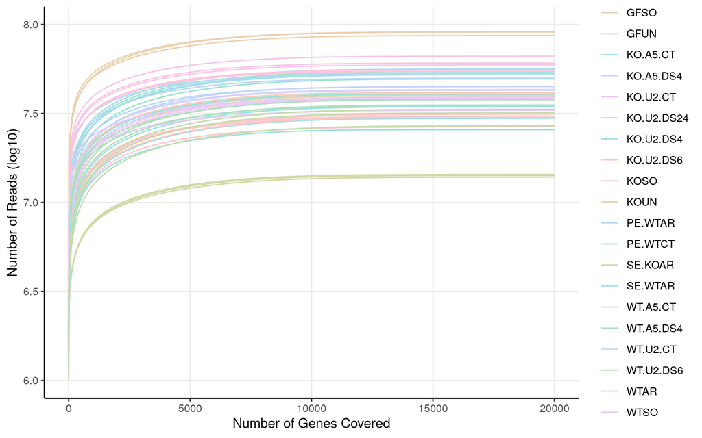

```r
# Define color palette
custom_palette <- qualitative_hcl(20, palette = "Pastel")
custom_palette <- sample(custom_palette, 20)

# Use SampleColouring from metadata
SampleColouring <- c("PE.WTCT", "PE.WTCT", "PE.WTCT", "PE.WTAR", "PE.WTAR", "PE.WTAR", "SE.WTAR", "SE.WTAR", "SE.WTAR", "SE.KOAR", "SE.KOAR", "SE.KOAR", "WTAR", "WTAR", "WTAR", "WTSO", "WTSO", "WTSO", "KOSO", "KOSO", "GFUN", "GFUN", "GFUN", "KOUN", "KOUN", "KOUN", "GFSO", "GFSO", "GFSO", rep("WT.U2.CT",2), rep("WT.U2.DS6",2), rep("KO.U2.CT",2),rep("KO.U2.DS4",2), rep("WT.A5.CT",2), rep("WT.A5.DS4",2), rep("KO.A5.CT",2), rep("KO.A5.DS4",2), rep("KO.U2.DS6",3), rep("KO.U2.DS24",3))

# Build cumulative counts
final <- sapply(1:ncol(read.counts), function(i) {
  sort_vals <- read.counts[order(read.counts[, i], decreasing = TRUE), i]
  cumsum(sort_vals)
})
final <- as.data.frame(final)
colnames(final) <- colnames(read.counts)

# Melt and add gene position + sample info
finalmelt <- reshape2::melt(final, variable.name = "Sample")
finalmelt$genes <- rep(1:nrow(final), times = ncol(final))
finalmelt$SampleColouring <- rep(SampleColouring, each = nrow(final))

# Plot cumulative read coverage
ggplot(data = finalmelt, aes(x = genes, y = log10(value), group = Sample, color = SampleColouring)) +
  geom_line() +
  scale_color_manual(values = custom_palette, name = "Cell Line") +
  theme_bw() +
  xlab("Number of Genes Covered") +
  ylab("Number of Reads (log10)") +
  xlim(0, 20000) +
  ylim(6, 8) +
  theme(
    axis.line = element_line(colour = "black"),
    panel.grid.minor = element_blank(),
    panel.border = element_blank(),
    panel.background = element_blank()
  )
```

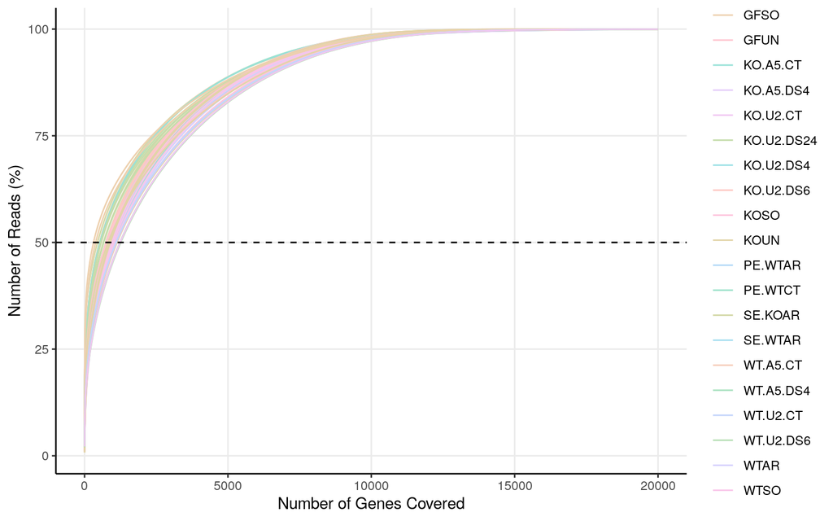

```r
# Create percentage-based plot
orderfinal <- subset(finalmelt, genes == max(finalmelt$genes))
trial <- merge(orderfinal[, c("Sample", "value")], finalmelt, by = "Sample", suffixes = c(".total", ".current"))
trial$percent <- (trial$value.current / trial$value.total) * 100
trial$SampleColouring <- rep(SampleColouring, each = nrow(final))

ggplot(data = trial, aes(x = genes, y = percent, group = Sample, color = SampleColouring)) +
  geom_line() +
  geom_hline(yintercept = 50, linetype = "dashed") +
  scale_color_manual(values = custom_palette, name = "Cell Line") +
  xlab("Number of Genes Covered") +
  ylab("Number of Reads (%)") +
  xlim(0, 20000) +
  theme_bw() +
  theme(
    axis.line = element_line(colour = "black"),
    panel.grid.minor = element_blank(),
    panel.border = element_blank(),
    panel.background = element_blank()
  )
```